# Class_projectpdf

Kemi

2024-12-02

#Preliminatry idea for title How Do Journalists Remember Themselves? Dominant Themes in Articles Commemorating Assassinated Nigerian Journalist, Dele Giwa

# Summary of final project

This study examines four hundred and fifty four commemorative articles about assasinated Nigerian journalist, Dele Giwa, to identify the dominant themes. The study also analyzes differences in the commemoration during the military era (1987 to May 1999) and civilian (1999 to 2023).

# Research Questions

1. What are the dominant themes in the articles commemorating Dele Giwa’s assassination?
2. What are the differences in the commemoration of Dele Giwa between the military era (Oct 1987 to May 1999) and the civilian era (May 1999 to Oct 2023)?

# content analysis plan

The 454 articles were loaded into R, cleaned and prepared for analysis. The unit of analysis are news and opinion articles about Dele Giwa. The following analysis were run with the ultimate aim of identifying dominant themes: Bigrams: The dataset was tokenized and then analyzed for bigrams to reveal the top phrases. Topic modelling: Latent Dirichlet Allocation (LDA) was used to cluster words into topics. This will also be used to examine how the themes evolve over time (military vs. civilian era). Sentiment analysis: The NRC dictionary will be used to analyze the overall tone of the articles. (Not sure about this yet because I think this won’t bring anything special)

# Coding scheme

Below is a coding scheme developed based on the literature and my familiarization with the data:

Bravery and Sacrifice: Mentions of Dele Giwa’s courage, investigative prowess, or ultimate sacrifice for truth and justice.

Calls for Justice: different expressions advocating for justice or accountability for his assassination.

Criticism of Authorities: Critical reflections on the failure of successive governments, law enforcement, or judiciary to solve the murder will fall under this category

Freedom of the Press: Themes highlighting press freedom and the risks journalists face in Nigeria.

Comparison of Eras: Contrasts between the military and civilian eras in terms of press freedom, accountability, or socio-political environment.

Role Model: Description of Dele Giwa as an icon of good journalism whose work inspires other journalists.

# Load libraries

```r
library(pdftools)
library(tidyverse)
library(stringr)
library(readxl)
library(rio)
library(tidytext)
library(dplyr)
library(tidyr)
```

## link to dataset on GitHub

```r
#link - https://github.com/kemibus/kemi_new/blob/main/dele.PDF
```

# Read text from a PDF file

```r
# Specify the file path
#filepath <- "~/GitHub/kemi_new/dele.PDF"
#Read pdf and coverting it into text
text <- pdf_text("~/GitHub/kemi_new/dele.PDF")
#write to a text file
writeLines (text, "~/GitHub/kemi_new/dele.text")
```

# Split the text to have one article per file

```r
#Read the text from the PDF
#dele_text <- pdf_text("~/GitHub/kemi_new/dele.PDF")
file_path <- ("~/GitHub/kemi_new/dele.text")
text_data <- read_lines(file_path)
# Combine all the pages into one text
text_combined <- paste(text_data, collapse = "\n")

# Split the text by the "End of Document" phrase
dele_split <- strsplit(text_combined, "End of Document")[[1]]

# Set the output directory for saving the split files
output_dir <- "~/GitHub/kemi_new/dele_extracted"

# Write each section to a new text file
for (i in seq_along(dele_split)) {
  output_file <- file.path(output_dir, paste0("dele_extracted", i, ".txt"))
  writeLines(dele_split[[i]], output_file)
}

# Print a message to confirm how many files were created
cat("Files created:", length(dele_split), "\n")
```

```
## Files created: 455
```

## Extract lines to create index

```r
dele_index <- read_lines("~/GitHub/kemi_new/dele_extracted/dele_extracted1.txt")
extracted_lines <-dele_index[16:1504]
cat(head(extracted_lines, 7), sep = "\n")
```

```
##
##   1. Remembering Dele Giwa
##
##
##   2. Dele Giwa's Death: 37yrs After, Council Chairman Establishes Essay Competition
```

```r
extracted_lines <- extracted_lines |>
  as.data.frame()
```

## Build a final dataframe index

## Add data from the excel sheet

```r
final_data <- rio::import("dele_list.XLSX") |> #with the new index
  janitor::clean_names() |>
   mutate(date = as.Date(strptime(published_date, "%B %d, %Y"), "%Y-%m-%d")) |>
  mutate(index = row_number()) |>
  mutate(year=year(date))
```

## Raw text compiler

```r
# List all text files in the directory
files <- list.files("~/GitHub/kemi_new/dele_extracted", pattern="*.txt") |>
  as.data.frame() |>
  rename(filename = 1) |>
  mutate(
    # Create an index with the file name
    index = str_extract(filename, "\\d+"),
    index = as.numeric(index)
  )

# Join the file list to the final_data dataframe based on index
final_index <- final_data |>
  inner_join(files, c("index")) |>
  mutate(filepath = paste0("~/GitHub/kemi_new/dele_extracted/", filename))

# Display the head of the compiled dataframe with filenames and content
head(final_index)
```

```
##                                                                                                          title
## 1                                                                                        Remembering Dele Giwa
## 2                               Dele Giwa's Death: 37yrs After, Council Chairman Establishes Essay Competition
## 3                                                                    Letter bomb did not kill Dele Giwa — Saka
## 4                                        AFRICMIL invites young journalists to submit essays on late Dele Giwa
## 5 37 years after Giwa's death: Etsako council chairman set up secondary school essay competition in his honour
## 6                                             Utomi, Falana to attend lecture in honour of #EndSARS, Dele Giwa
##                published_date publication_location               publication_4
## 1   October 19, 2023 Thursday        International        The Nation (Nigeria)
## 2     October 20, 2023 Friday        International Daily Independent (Nigeria)
## 3     October 20, 2023 Friday        International             Opinion Nigeria
## 4 September 18, 2021 Saturday        International        The Nation (Nigeria)
## 5     October 20, 2023 Friday        International           The Sun (Nigeria)
## 6     October 17, 2021 Sunday        International                   The Punch
##   publication_type_5 length section word_count                    countries
```

[output cut: 48 more lines]

## Remove items in the bracket in final index

## Merge “Weekly Trust” into “Daily Trust”, they are the same

```r
final_index <- final_index %>%
  mutate(publication_4 = str_replace(publication_4, "Weekly Trust", "Daily Trust"))
```

## Number of rows - 454

```r
nrow(final_index)
```

```
## [1] 454
```

```r
ncol(final_index)
```

```
## [1] 26
```

## Count the number of articles per year

```r
# Count the number of articles published per year and arrange by year
articles_per_year <- final_index %>%
  count(year) %>%
  filter(!is.na(year)) %>%
  arrange(year)

# View the count of articles per year
print(articles_per_year)
```

```
##    year  n
## 1  1986  5
## 2  1990  1
## 3  1992  1
## 4  1993  1
## 5  1995  1
## 6  1996  2
## 7  1998  1
## 8  1999  2
## 9  2000  2
## 10 2001  3
## 11 2002  3
## 12 2005  1
## 13 2006  1
## 14 2009  1
## 15 2010 53
## 16 2011 18
## 17 2012 21
## 18 2013 19
## 19 2014 26
## 20 2015 34
## 21 2016 24
## 22 2017 22
## 23 2018 36
## 24 2019 23
## 25 2020 27
## 26 2021 45
## 27 2022 33
## 28 2023 47
```

## Visualize articles per year in a table

```r
# Load the DT package
library(DT)
articles_per_year_table <- articles_per_year %>%
  arrange(year)

# Create an interactive table
datatable(articles_per_year_table,
          options = list(
            pageLength = 10,    # Number of rows per page
            autoWidth = TRUE,   # Automatically adjust column width
            searching = FALSE,  # Disable search bar
            ordering = TRUE     # Allow sorting of columns
          )) %>%
  formatStyle(
    'n', # Target the column 'n' (Number of Articles)
    backgroundColor = styleInterval(0, c('#f2f2f2', '#d9f2d9')), # Add alternating row colors
    fontWeight = 'bold'  # Make the font bold
  )
```

|  | year | n |
| --- | --- | --- |
| 1 | 1986 | 5 |
| 2 | 1990 | 1 |
| 3 | 1992 | 1 |
| 4 | 1993 | 1 |
| 5 | 1995 | 1 |
| 6 | 1996 | 2 |
| 7 | 1998 | 1 |
| 8 | 1999 | 2 |
| 9 | 2000 | 2 |
| 10 | 2001 | 3 |

[output cut: 18 more lines]

## Identify the top ten years with the most publications

```r
top_10 <- articles_per_year %>%
  top_n(10, n) %>%
  arrange(desc(n))
```

## Visualize top 10

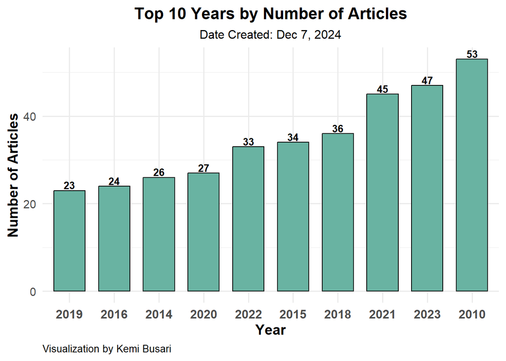

```r
top_10_plot <- top_10 %>%
  ggplot(aes(x = reorder(factor(year), n), y = n)) +
  geom_bar(stat = "identity", fill = "#69b3a2", color = "black", width = 0.7) +
  geom_text(aes(label = n), vjust = -0.2, size = 3.5, fontface = "bold", color = "black") +
  labs(
    title = "Top 10 Years by Number of Articles",
    subtitle = "Date Created: Dec 7, 2024",
    caption = "Visualization by Kemi Busari",
    x = "Year",
    y = "Number of Articles"
  ) +
  theme_minimal(base_size = 14) +
  theme(
    plot.title = element_text(face = "bold", size = 16, hjust = 0.5),
    plot.subtitle = element_text(size = 12, hjust = 0.5),
    plot.caption = element_text(hjust = 0, size = 10),
    axis.text.x = element_text(face = "bold", size = 12),
    axis.title = element_text(face = "bold")
  )

# Print the plot
print(top_10_plot)
```

## count the number of articles in military era(1986 to 1999)

```r
articles_1986_1999 <- final_index %>%
  filter(year >= 1986 & year <= 1999) %>%
  count(year)
```

#Only 14 articles were published during the military era

## count the number of articles in the democratic era(2000 to 2023)

```r
articles_2000_2023 <- final_index %>%
  filter(year >= 2000 & year <= 2023) %>%
  count(year)
total_articles_2000_2023 <- sum(articles_2000_2023$n)

# Print the yearly breakdown and total articles
print(articles_2000_2023)
```

```
##    year  n
## 1  2000  2
## 2  2001  3
## 3  2002  3
## 4  2005  1
## 5  2006  1
## 6  2009  1
## 7  2010 53
## 8  2011 18
## 9  2012 21
## 10 2013 19
## 11 2014 26
## 12 2015 34
## 13 2016 24
## 14 2017 22
## 15 2018 36
## 16 2019 23
## 17 2020 27
## 18 2021 45
## 19 2022 33
## 20 2023 47
```

```r
print(total_articles_2000_2023)
```

```
## [1] 439
```

### 439 articles were published in the democratic era (2000 - 2023)

## Count the number of articles published by each newspaper

```r
articles_per_newspaper <- final_index %>%
  count(publication_4) %>%
  group_by(publication_4) %>%
  summarise(total_articles = sum(n)) %>%
  arrange(desc(total_articles))
```

44 news platforms published about Dele Giwa

## Extract top 10 newspapers

```r
top_10_newspapers <- articles_per_newspaper %>%
  arrange(desc(total_articles)) %>%
  slice(1:10)
```

## Visualize top 10

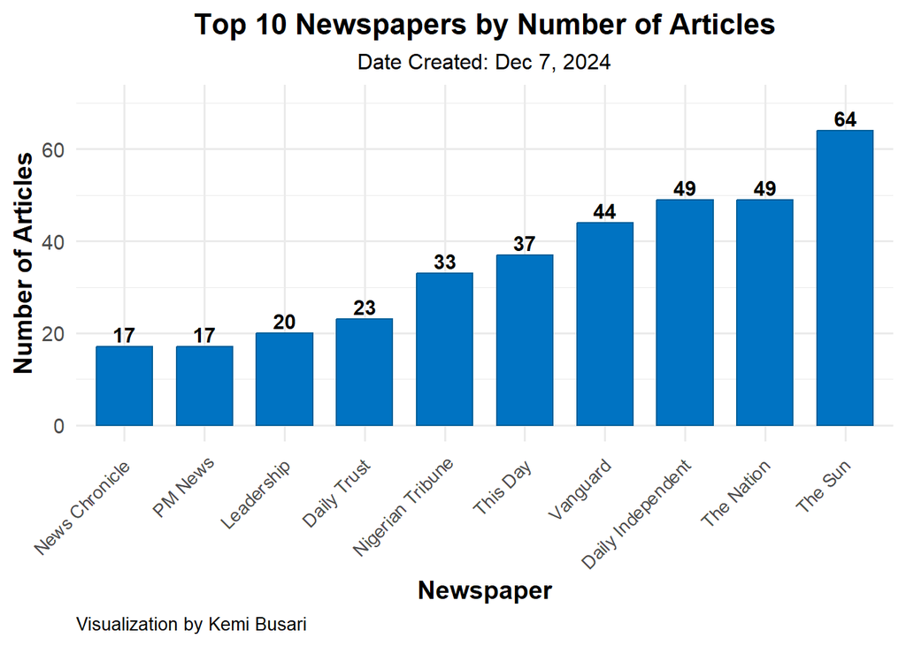

```r
top_10_newspapers_plot <- top_10_newspapers %>%
  ggplot(aes(x = reorder(publication_4, total_articles), y = total_articles)) +
  geom_bar(stat = "identity", fill = "#0073C2FF", color = "#005f99", width = 0.7) +
  geom_text(aes(label = total_articles), vjust = -0.3, size = 4, fontface = "bold", color = "black") +
  labs(
    title = "Top 10 Newspapers by Number of Articles",
    subtitle = "Date Created: Dec 7, 2024",
    caption = "Visualization by Kemi Busari",
    x = "Newspaper",
    y = "Number of Articles"
  ) +
  theme_minimal(base_size = 14) +
  theme(
    plot.title = element_text(face = "bold", size = 16, hjust = 0.5),
    plot.subtitle = element_text(size = 12, hjust = 0.5),
    plot.caption = element_text(hjust = 0, size = 10),
    axis.text.x = element_text(angle = 45, hjust = 1, vjust = 1, size = 10),
    axis.title = element_text(face = "bold")
  ) +
  # Adjust the y-axis limit to ensure the highest bar and its label are visible
  ylim(0, max(top_10_newspapers$total_articles) * 1.1)

# Print the plot
print(top_10_newspapers_plot)
```

## bigrams

```r
# Load necessary libraries
library(dplyr)
library(tidytext)
library(stringr)
# Process bigrams
bigrams <- articles_df %>%
  select(sentence) %>%
  mutate(
    sentence = str_squish(sentence),
    sentence = tolower(sentence),
    sentence = str_replace_all(sentence, c(
      "copyright" = "",
      "new york times" = "",
      "publication" = "",
      "www.alt" = "",
      "http" = ""
    ))
  ) %>%
  unnest_tokens(bigram, sentence, token = "ngrams", n = 2) %>%
  separate(bigram, c("word1", "word2"), sep = " ") %>%
  filter(!word1 %in% stop_words$word) %>%                 # Filter out stop words
  filter(!word2 %in% stop_words$word) %>%
  count(word1, word2, sort = TRUE) %>%
  filter(!is.na(word1) & !is.na(word2))

# Ensure `stop_words` data is available
data("stop_words")

# Define the expanded remove pattern for unwanted terms
remove_pattern <- paste(
  "title", "pages", "publication date", "publication subject", "publication type",
  "issn", "language of publication: english", "document url", "copyright", "news", "lenght", "words", "load", "date", "live updates", "updates assembly", "polling", "units", "total votes",
  "service last updated", "database", "start of article", "rights reserved",
  "local assembly", "local government", "ups assembly", "live ups", "elections",
  "accredited voters", "governorship", "registered", "total", "votes", "cast",
  "valid", "rejected", "polling units", "electoral commission",
  "progressives congress", "independent", "inec", "presidential", "proquest document id",
  "classification", "illustration", "caption", "[0-9.]+", "_ftn", "[_]+", "aaa",
  "jcr:fec", "___________________", "rauchway", "keynes's", "language", "english",
  "length words", "global media", "allafrica global", "syndigate media",
  "peoples democratic", "party pdp", "returning officer", "akwa ibom",
  "managing director", "publishing limited", "sun publishing", "sun nigeria", "party pdp", sep = "|"
)

# Process bigrams again with the updated remove pattern
bigrams <- articles_df %>%
  select(sentence) %>%
  mutate(
    sentence = str_squish(sentence),                      # Remove extra spaces
    sentence = tolower(sentence),                         # Convert to lowercase
    sentence = str_replace_all(sentence, remove_pattern, ""), # Remove unwanted terms
    sentence = str_replace_all(sentence, "- ", ""),       # Remove trailing hyphens
    sentence = str_replace_all(sentence, "\\b[a-zA-Z]\\b", "") # Remove single characters
  ) %>%
  unnest_tokens(bigram, sentence, token = "ngrams", n = 2) %>%
  separate(bigram, c("word1", "word2"), sep = " ") %>%
  filter(!word1 %in% stop_words$word) %>%                 # Filter out stop words
  filter(!word2 %in% stop_words$word) %>%
  filter(!word1 %in% remove_pattern) %>%
  count(word1, word2, sort = TRUE) %>%
  filter(!is.na(word1) & !is.na(word2))                   # Filter out NAs

# Display the processed bigrams
print(bigrams)
```

```
## # A tibble: 56,610 × 3
##    word1    word2         n
##    <chr>    <chr>     <int>
##  1 dele     giwa       1089
##  2 human    rights      184
##  3 ray      ekpu        176
##  4 parcel   bomb        154
##  5 letter   bomb        141
##  6 daily    times       138
##  7 ibrahim  babangida   130
##  8 watch    magazine    130
##  9 boko     haram       128
## 10 national assembly    118
## # ℹ 56,600 more rows
```

## Top 20 bigrams

```r
top_bigrams <- bigrams %>%
  arrange(desc(n)) %>%
  head(20)
print(top_bigrams)
```

```
## # A tibble: 20 × 3
##    word1      word2             n
##    <chr>      <chr>         <int>
##  1 dele       giwa           1089
##  2 human      rights          184
##  3 ray        ekpu            176
##  4 parcel     bomb            154
##  5 letter     bomb            141
##  6 daily      times           138
##  7 ibrahim    babangida       130
##  8 watch      magazine        130
##  9 boko       haram           128
## 10 national   assembly        118
## 11 journalist dele            111
## 12 giwa       death           108
## 13 security   agencies        107
## 14 olusegun   obasanjo        103
## 15 federal    government       95
## 16 mass       communication    94
## 17 dimgba     igwe             91
## 18 party      pdp              87
## 19 press      freedom          83
## 20 giwa       murder           79
```

## Visualize top 20 bigrams

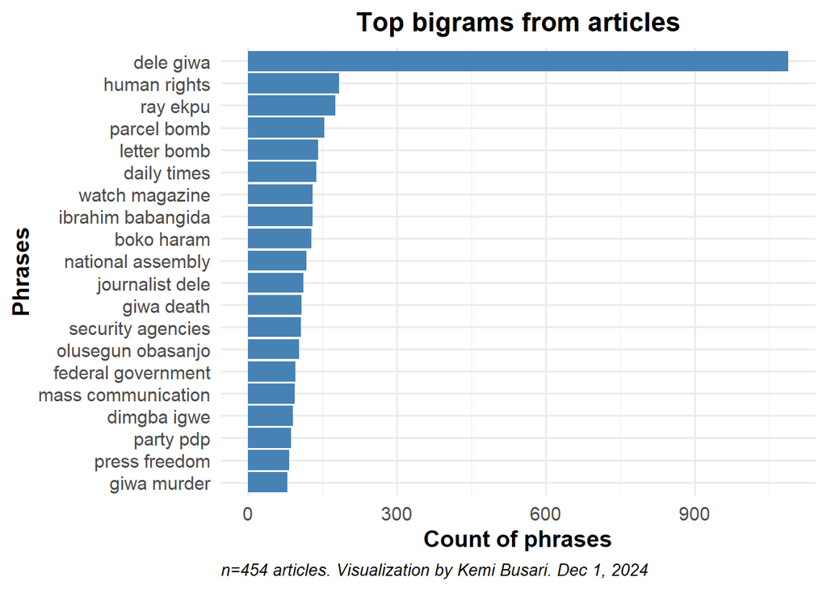

```r
# Ensure the required libraries are loaded
ggplot(top_bigrams, aes(x = reorder(paste(word1, word2, sep = " "), n), y = n)) +
  geom_col(fill = "steelblue") +
  coord_flip() +
  labs(
    title = "Top bigrams from articles",
    caption = "n=454 articles. Visualization by Kemi Busari. Dec 1, 2024",
    x = "Phrases",
    y = "Count of phrases"
  ) +
  theme_minimal(base_size = 14) +
  theme(
    plot.title = element_text(hjust = 0.5, face = "bold", size = 16),
    plot.caption = element_text(hjust = 0, face = "italic", size = 10),
    axis.title.x = element_text(face = "bold"),
    axis.title.y = element_text(face = "bold")
  )
```

# Sentiment Analysis

```r
library(textdata)
library(quanteda)
```

## Tokenize text

```r
text_tokenized <- articles_df %>%
  select(sentence) %>%
  unnest_tokens(word, sentence)
```

## Filter tokenized text

```r
text_tokenized <- articles_df %>%
  select(sentence) %>%
  mutate(sentence = str_replace_all(sentence, "- ", "")) %>%
  unnest_tokens(word, sentence) %>%
  filter(!word %in% stop_words$word) %>%
  filter(word != "stories_corpus") %>%
  filter(!grepl('[0-9]', word))
```

## Word count

```r
text_word_ct <- text_tokenized %>%
  count(word, sort=TRUE)
text_word_ct
```

```
## # A tibble: 27,040 × 2
##    word            n
##    <chr>       <int>
##  1 nigeria      2340
##  2 page         1629
##  3 people       1613
##  4 media        1506
##  5 journalists  1505
##  6 government   1469
##  7 dele         1326
##  8 giwa         1326
##  9 nigerian     1180
## 10 lagos        1033
## # ℹ 27,030 more rows
```

## Load NRC lexicon

```r
nrc_sentiments <- get_sentiments("nrc")

nrc_sentiments %>% count(sentiment)
```

```
## # A tibble: 10 × 2
##    sentiment        n
##    <chr>        <int>
##  1 anger         1245
##  2 anticipation   837
##  3 disgust       1056
##  4 fear          1474
##  5 joy            687
##  6 negative      3316
##  7 positive      2308
##  8 sadness       1187
##  9 surprise       532
## 10 trust         1230
```

```r
nrc_sentiments %>%
  group_by(word) %>%
  count() %>%
  arrange(desc(n)) %>%
  distinct()
```

```
## # A tibble: 6,453 × 2
## # Groups:   word [6,453]
##    word          n
##    <chr>     <int>
##  1 feeling      10
##  2 treat        10
##  3 weight        9
##  4 celebrity     8
##  5 intense       8
##  6 obliging      8
##  7 opera         8
##  8 supremacy     8
##  9 vote          8
## 10 death         7
## # ℹ 6,443 more rows
```

## Count Overall Sentiment with NRC

```r
sentiments_all <- text_tokenized %>%
  inner_join(nrc_sentiments)
sentiments_all %>%
  group_by(word) %>%
    count(sentiment) %>%
  arrange(desc(n))
```

```
## # A tibble: 9,308 × 3
## # Groups:   word [4,171]
##    word       sentiment        n
##    <chr>      <chr>        <int>
##  1 government fear          1469
##  2 government negative      1469
##  3 time       anticipation  1014
##  4 journalist positive       966
##  5 president  positive       965
##  6 president  trust          965
##  7 journalism trust          954
##  8 military   fear           826
##  9 police     fear           822
## 10 police     positive       822
## # ℹ 9,298 more rows
```

```r
sentiments_all <- text_tokenized %>%
  inner_join(nrc_sentiments) %>%
  count(sentiment, sort = TRUE) %>%
  mutate(pct_total =round(n/sum(n), digits=2))
sentiments_all
```

```
## # A tibble: 10 × 3
##    sentiment        n pct_total
##    <chr>        <int>     <dbl>
##  1 positive     39226      0.22
##  2 trust        27741      0.16
##  3 negative     24749      0.14
##  4 fear         18302      0.1
##  5 anticipation 16233      0.09
##  6 anger        13082      0.07
##  7 sadness      11421      0.07
##  8 joy          10493      0.06
##  9 surprise      7551      0.04
## 10 disgust       6715      0.04
```

## Create ggplot

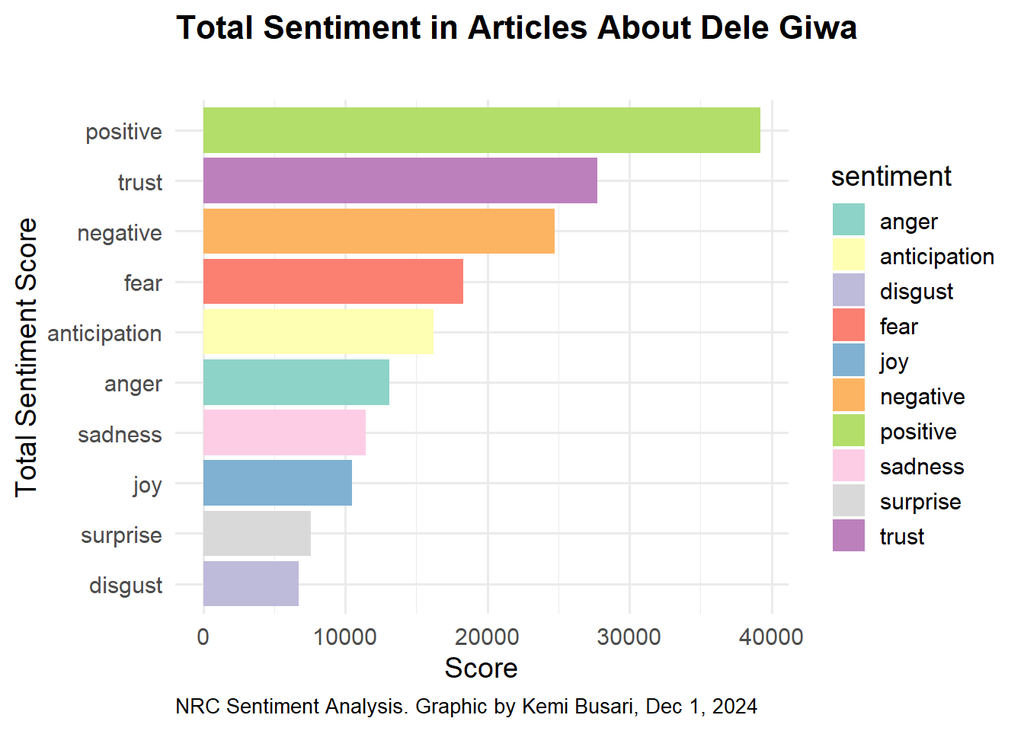

```r
# Load necessary libraries
library(ggplot2)
library(dplyr)

# Plot the sentiment analysis results
nrc_plot <- sentiments_all %>%
  ggplot(aes(x = reorder(sentiment, n), y = n, fill = sentiment)) +
  geom_bar(stat = "identity", position = "dodge") +
  theme(legend.position = "none") +
  labs(
    title = "Total Sentiment in Articles About Dele Giwa",
    subtitle = " ",
    caption = "NRC Sentiment Analysis. Graphic by Kemi Busari, Dec 1, 2024",
    x = "Total Sentiment Score",
    y = "Score"
  ) +
  theme_minimal(base_size = 14) +
  theme(
    plot.title = element_text(face = "bold", size = 16),
    plot.caption = element_text(hjust = 0, size = 10)
  ) +
  scale_fill_brewer(palette = "Set3") +
  coord_flip()

# Print the plot
print(nrc_plot)
```

# Group by sentiment and word, then count the occurrences

```r
# Load necessary libraries
library(dplyr)

# Join the tokenized text with sentiment data
sentiments_all <- text_tokenized %>%
  inner_join(nrc_sentiments)
# Group by sentiment and word, then count the occurrences
top_words_per_sentiment <- sentiments_all %>%
  count(sentiment, word) %>%
  arrange(sentiment, desc(n)) %>%
  group_by(sentiment) %>%
  slice_max(n, n = 5, with_ties = FALSE)  # Get top 5 words for each sentiment

# View the result
print(top_words_per_sentiment)
```

```
## # A tibble: 50 × 3
## # Groups:   sentiment [10]
##    sentiment    word       n
##    <chr>        <chr>  <int>
##  1 anger        death    730
##  2 anger        words    615
##  3 anger        murder   500
##  4 anger        bomb     499
##  5 anger        court    478
##  6 anticipation time    1014
##  7 anticipation death    730
##  8 anticipation public   548
##  9 anticipation god      489
## 10 anticipation court    478
## # ℹ 40 more rows
```

## Extract top two words in each sentiment

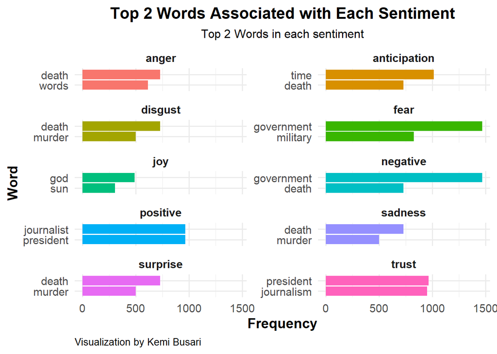

```r
# Create the plot showing only the top 3 words per sentiment
sentiment_plot <- top_words_per_sentiment %>%
  group_by(sentiment) %>%
  top_n(2, n) %>%  # Select the top 3 words for each sentiment
  ungroup() %>%
  ggplot(aes(x = reorder(word, n), y = n, fill = sentiment)) +
  geom_bar(stat = "identity", show.legend = FALSE) +  # Create bar chart
  facet_wrap(~sentiment, scales = "free_y", ncol = 2) +  # Facet by sentiment
  labs(
    title = "Top 2 Words Associated with Each Sentiment",
    subtitle = "Top 2 Words in each sentiment",
    x = "Word",
    y = "Frequency",
    caption = "Visualization by Kemi Busari"
  ) +
  coord_flip() +  # Flip the axes for readability
  theme_minimal(base_size = 14) +
  theme(
    plot.title = element_text(face = "bold", size = 16, hjust = 0.5),
    plot.subtitle = element_text(size = 12, hjust = 0.5),
    plot.caption = element_text(hjust = 0, size = 10),
    axis.title = element_text(face = "bold"),
    strip.text = element_text(face = "bold")
  )

# Print the plot
print(sentiment_plot)
```

## Check the words in some of the sentiments

# Positive

```r
nrc_positive <- nrc_sentiments %>%
  filter(sentiment == "positive")
dele_positive <- text_tokenized %>%
  inner_join(nrc_positive) %>%
  count(word, sort = TRUE)
dele_positive
```

```
## # A tibble: 1,663 × 2
##    word            n
##    <chr>       <int>
##  1 journalist    966
##  2 president     965
##  3 police        822
##  4 assembly      557
##  5 public        548
##  6 god           489
##  7 university    413
##  8 concord       372
##  9 justice       357
## 10 information   330
## # ℹ 1,653 more rows
```

# Trust

```r
#Trust
nrc_trust <- nrc_sentiments %>%
  filter(sentiment == "trust")
dele_trust <- text_tokenized %>%
  inner_join(nrc_trust) %>%
  count(word, sort = TRUE)
dele_trust
```

```
## # A tibble: 912 × 2
##    word           n
##    <chr>      <int>
##  1 president    965
##  2 journalism   954
##  3 police       822
##  4 assembly     557
##  5 nation       557
##  6 god          489
##  7 governor     488
##  8 school       476
##  9 law          398
## 10 concord      372
## # ℹ 902 more rows
```

# Negative

```r
nrc_negative <- nrc_sentiments %>%
  filter(sentiment == "negative")
dele_negative <- text_tokenized %>%
  inner_join(nrc_negative) %>%
  count(word, sort = TRUE)
dele_negative
```

```
## # A tibble: 2,021 × 2
##    word           n
##    <chr>      <int>
##  1 government  1469
##  2 death        730
##  3 words        615
##  4 murder       500
##  5 bomb         499
##  6 late         473
##  7 war          290
##  8 rejected     234
##  9 corruption   215
## 10 lost         213
## # ℹ 2,011 more rows
```

# Fear

```r
nrc_fear <- nrc_sentiments %>%
  filter(sentiment == "fear")
dele_fear <- text_tokenized %>%
  inner_join(nrc_fear) %>%
  count(word, sort = TRUE)
dele_fear
```

```
## # A tibble: 988 × 2
##    word           n
##    <chr>      <int>
##  1 government  1469
##  2 military     826
##  3 police       822
##  4 death        730
##  5 murder       500
##  6 bomb         499
##  7 god          489
##  8 court        478
##  9 war          290
## 10 killing      205
## # ℹ 978 more rows
```

# Anticipation

```r
nrc_anticipation <- nrc_sentiments %>%
  filter(sentiment == "anticipation")
dele_anticipation <- text_tokenized %>%
  inner_join(nrc_anticipation) %>%
  count(word, sort = TRUE)
dele_anticipation
```

```
## # A tibble: 624 × 2
##    word           n
##    <chr>      <int>
##  1 time        1014
##  2 death        730
##  3 public       548
##  4 god          489
##  5 court        478
##  6 daily        416
##  7 university   413
##  8 sun          303
##  9 letter       288
## 10 money        285
## # ℹ 614 more rows
```

# Anger

```r
nrc_anger <- nrc_sentiments %>%
  filter(sentiment == "anger")
dele_anger <- text_tokenized %>%
  inner_join(nrc_anger) %>%
  count(word, sort = TRUE)
dele_anger
```

```
## # A tibble: 851 × 2
##    word         n
##    <chr>    <int>
##  1 death      730
##  2 words      615
##  3 murder     500
##  4 bomb       499
##  5 court      478
##  6 money      285
##  7 politics   277
##  8 limited    206
##  9 killing    205
## 10 coup       199
## # ℹ 841 more rows
```

## Sentiment during military era - 1986-1999

```r
# Filter the data for the years between 1986 and 1999
#military_sentiment <- articles_df %>%
  ##filter(year >= 1986 & year <= 1999) %>%  # Filter for the years 1986-1999
  #group_by(sentiment) %>%  # Group by sentiment
  #count(sentiment, sort = TRUE)  # Count the number of occurrences of each sentiment

# View the military_sentiment
#print(military_sentiment)
```

## Sentiment in the democratic era - 2000 -2023

```r
#military_sentiment <-  articles_df %>%
  #filter(year >= 2000 & year <=2023)
```

Note: These two codes did not work still. Will keep working on them.

# Topic modelling

#Install and load packages

```r
# install.packages("here")
# install.packages("tidytext")
# install.packages("quanteda")
# install.packages("tm")
# install.packages("topicmodels")
# install.packages("reshape2")
# install.packages("ggplot2")
# install.packages("wordcloud")
# install.packages("pals")
# install.packages("SnowballC")
# install.packages("lda")
# install.packages("ldatuning")
# install.packages("kableExtra")
# install.packages("DT")
# install.packages("flextable")
# install.packages("remotes")
# remotes::install_github("rlesur/klippy")
#install.packages("rio")
#install.packages("readtext")
#install.packages("formattable")
```

## Process into corpus object

```r
topic_data <- articles_df %>%
  select(filename, sentence) %>%
  as.data.frame() %>%
  rename(doc_id = filename, text= sentence)

# load stopwords
english_stopwords <- readLines("https://slcladal.github.io/resources/stopwords_en.txt", encoding = "UTF-8")
# create corpus object
corpus <- Corpus(DataframeSource(topic_data))
# Preprocessing chain
processedCorpus <- tm_map(corpus, content_transformer(tolower))
processedCorpus <- tm_map(processedCorpus, removeWords, english_stopwords)
processedCorpus <- tm_map(processedCorpus, removePunctuation, preserve_intra_word_dashes = TRUE)
processedCorpus <- tm_map(processedCorpus, removeNumbers)
processedCorpus <- tm_map(processedCorpus, stemDocument, language = "en")
processedCorpus <- tm_map(processedCorpus, stripWhitespace)
```

```r
#DTM: rows correspond to the documents in the corpus. Columns correspond to the terms in the documents. Cells correspond to the weights of the terms. (Girder)
# compute document term matrix with terms >= minimumFrequency
minimumFrequency <- 5
DTM <- DocumentTermMatrix(processedCorpus, control = list(bounds = list(global = c(minimumFrequency, Inf))))
# have a look at the number of documents and terms in the matrix
dim(DTM)
```

```
## [1] 51458  6427
```

```r
# due to vocabulary pruning, we have empty rows in our DTM
# LDA does not like this. So we remove those docs from the
# DTM and the metadata
sel_idx <- slam::row_sums(DTM) > 0
DTM <- DTM[sel_idx, ]
topic_data <- topic_data[sel_idx, ]
#5 term minimum[1] 1387 3019
#5 term minimum[1] 308597 10339
```

## Topic proportions

```r
# number of topics
# K <- 20
K <- 6
# set random number generator seed
set.seed(9161)
#Latent Dirichlet Allocation, LDA
topicModel2 <- LDA(DTM, K, method="Gibbs", control=list(iter = 1000, verbose = 25, alpha = 0.2))
```

[output not shown]

```r
tmResult <- posterior(topicModel2)
theta <- tmResult$topics
beta <- tmResult$terms
topicNames <- apply(terms(topicModel2, 10), 2, paste, collapse = " ")  # reset topicnames
```

## Number of articles

```r
# Step 1: Check dimensions
n_theta <- nrow(theta)
n_topicdata<- length(topic_data)

cat("Number of rows in theta: ", n_theta, "\n")
```

```
## Number of rows in theta:  50495
```

```r
cat("Number of documents in textdata: ", n_topicdata, "\n")
```

```
## Number of documents in textdata:  2
```

```r
# Check if textdata contains all the documents in theta
common_ids <- intersect(rownames(theta), topic_data$doc_id) # Assuming textdata has a 'doc_id' column

# Filter textdata to include only the documents present in theta
topicdata_filtered <- topic_data[topic_data$doc_id %in% common_ids, ]

# Check dimensions after filtering
n_topicdata_filtered <- nrow(topicdata_filtered)
cat("Number of documents in filtered textdata: ", n_topicdata_filtered, "\n")
```

```
## Number of documents in filtered textdata:  50495
```

```r
# Align rownames of theta with filtered textdata
theta_aligned <- theta[rownames(theta) %in% topicdata_filtered$doc_id, ]

# Step 2: Combine data
full_data <- data.frame(theta_aligned, decade = topicdata_filtered)

# get mean topic proportions per decade
# topic_proportion_per_decade <- aggregate(theta, by = list(decade = textdata$decade), mean)
# set topic names to aggregated columns
colnames(full_data)[2:(K+1)] <- topicNames
# reshape data frame
vizDataFrame <- melt(full_data)
```

## Examine topic

```r
#enframe(): Converts a named list into a dataframe.
topics <- enframe(topicNames, name = "number", value = "text") %>%
  unnest(cols = c(text))

topics
```

```
## # A tibble: 6 × 2
##   number  text
##   <chr>   <chr>
## 1 Topic 1 govern presid countri nigeria militari polit peopl court nigerian nat…
## 2 Topic 2 giwa dele journalist kill murder polic death bomb lago load-dat
## 3 Topic 3 book journal school write ray read year univers nigerian stori
## 4 Topic 4 page media nigeria newspap report nation editor right time news
## 5 Topic 5 state vote elect pdp apc govern voter parti word unit
## 6 Topic 6 peopl man god life day time good thing nigeria live
```

## Review the topics

```r
theta2 <- as.data.frame(theta)

topic1 <- theta2 %>%
  rownames_to_column(var = "file") |> # putting the rownames into a new column called file
  mutate(file = str_remove(file, "^X"),  # Remove leading 'X'
         line = str_extract(file, "(?<=\\.txt)\\.\\d+")) |>   # Extract number after .txt
  mutate(file = str_remove(file, "\\.\\d+$")) |>
  rename(topic1 = '1') |>
  top_n(20, topic1) |>
  arrange(desc(topic1)) |>
  select(file, line, topic1)
```